# Part II - Ford GoBike System Data Exploration

## by Dorcas Misango

## Investigation Overview

In this investigation i would like to analyse the dataset especially where and at what time are most trips taken, and what kind of characteristics do these riders posses(sex, age, and user_type).

## Dataset Overview

This dataset includes 183,412 trips with 16 features. After cleaning the dataset had 10 rows i.e features:

- duration_sec
- start_time
- end_time
- start_station_name
- end_station_name
- bike_id
- user_type
- member_birth_year
- member_gender
- bike_share_for_all_trip

New rows were also added to the dataset :

- start_weekday
- start_hour
- end_hour
- duration_minutes

## Bike Usage

### Duration of bike rides

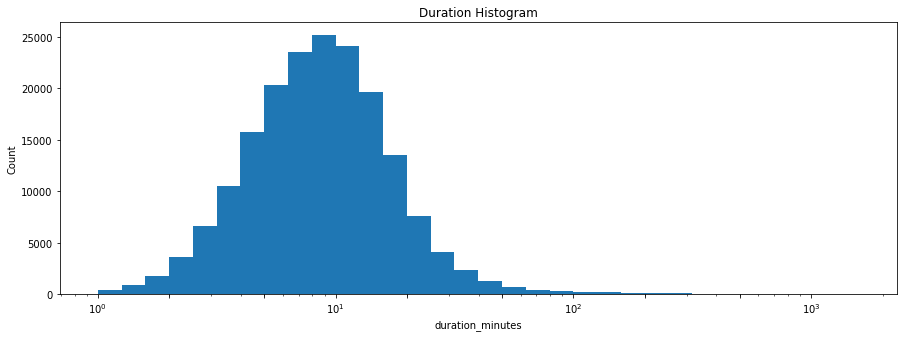

```python
# histogram with logarithmic scale transformation
plt.figure(figsize=[15,5])
bin_edges = 10 ** np.arange(0.0, np.log10(bike_df.duration_minutes.max())+0.1, 0.1)
plt.hist(data = bike_df, x = 'duration_minutes', bins = bin_edges)
plt.xscale('log')
tick_locs = [1, 2, 5, 10, 20, 50, 100, 200, 500, 1000]
plt.xticks(tick_locs)
x_y_t('duration_minutes','Count','Duration Histogram')
```

### Bike Usage (per day)

Contrary to what i believed the most popular days to begin rides were not the weekends and are actually weekdays, to be specific Thursday and Tuesday.

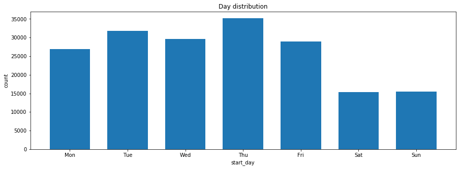

```python
# plot a histogram for days with gaps between bars
plt.figure(figsize=[15,5])
bin_edges = np.arange(-0.5, 6.5+1, 1)
plt.hist(data = bike_df, x = 'start_day', bins = bin_edges, rwidth = 0.7)
plt.xticks(np.arange(0, 6+1, 1), day_labels)
x_y_t('start_day','count','Day distribution')
```

### Bike Usage (per hour)

The number of trips gradually decreases during the later hours(after 7pm). During the day, there are more trips in the morning and evening.

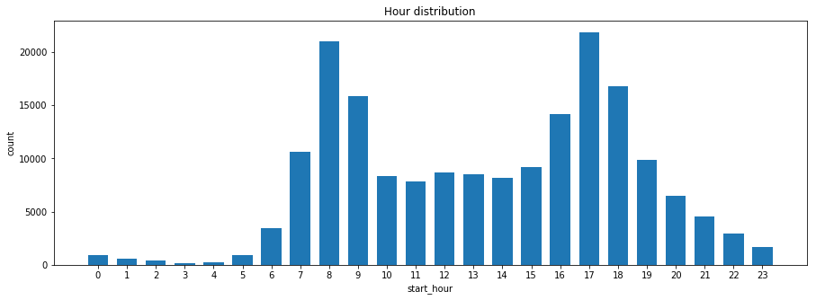

```python
# plot a histogram with gaps between bars
plt.figure(figsize=[15,5])
bin_edges = np.arange(-0.5, 23.5+1, 1)
plt.hist(data = bike_df, x = 'start_hour', bins = bin_edges, rwidth = 0.7)
plt.xticks(np.arange(0, 23+1, 1))
x_y_t('start_hour','count','Hour distribution')
```

### Bike usage in each user type and gender

subscribes are more likey to go on rides as compared to customers. men go on more rides as compared to women and others

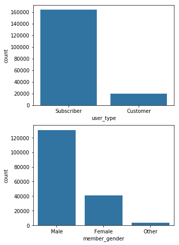

```python
# plot a bar chart
plt.figure(figsize=(5,8))
ax = plt.subplot(211)
user_type_order = bike_df['user_type'].value_counts().index
sb.countplot(data = bike_df, x = 'user_type', color = base_color, order = user_type_order);

ax = plt.subplot(212)
# plot a bar chart
member_gender_order = bike_df['member_gender'].value_counts().index
sb.countplot(data = bike_df, x = 'member_gender', color = base_color, order = member_gender_order);
```

### bike usage based on age

Most trips were traken by people in their thirties.

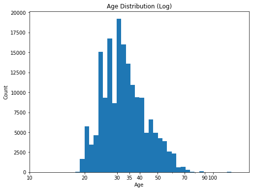

```python
bike_df.dropna(subset=['age'], inplace = True)
log_binsize = 0.025
bins = 10 ** np.arange(1.2, np.log10(bike_df['age'].max())+log_binsize, log_binsize)

plt.figure(figsize=[8, 6])
plt.hist(data = bike_df, x = 'age', bins = bins)
plt.xscale('log')
plt.xticks([10,20,30,35,40,50,70,90,100], [10,20,30,35,40,50,70,90,100])
x_y_t('Age','Count','Age Distribution (Log)')
```

## Most popular start stations

### Most popular station per day

The most popular station( Market St at 10th St) had the most traffic on Thursday. the other top stations also hasd the most traffic on either Tuesday or Thursday.

[figure not shown]

```python
start_order = bike_df['start_station_name'].value_counts().index[:10]
fig = plt.figure(figsize=(10,10))
plt.subplots_adjust(top=0.95)
sb.countplot(data=bike_df, y='start_station_name', hue='start_day', order = start_order)
plt.legend(['Mon', 'Tue', 'Wed', 'Thu', 'Fri', 'Sat', 'Sun'], loc='center left', bbox_to_anchor=(1,0.5))
x_y_t('Count','Start Station','Reationship between Start Station and Start Day')
```

### Most popular station by user type and gender

The most frequent user types in the popular stations were the subscribers.  
The most frequent gender were the males.

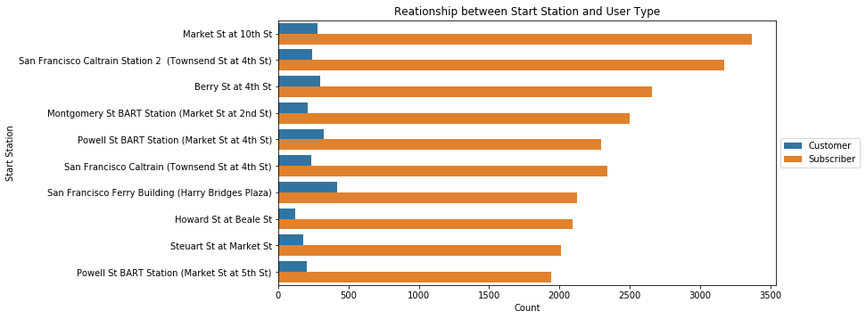

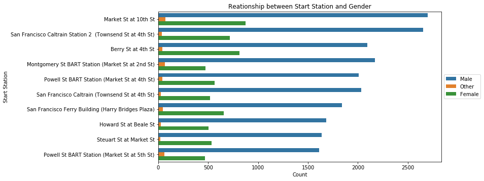

```python
start_order = bike_df['start_station_name'].value_counts().index[:10]
fig = plt.figure(figsize=(10,5))
plt.subplots_adjust(top=0.95)
sb.countplot(data=bike_df, y='start_station_name', hue='user_type', order = start_order)
plt.legend(loc='center left', bbox_to_anchor=(1,0.5))
x_y_t('Count','Start Station','Reationship between Start Station and User Type')

fig = plt.figure(figsize=(10,5))
plt.subplots_adjust(top=0.95)
sb.countplot(data=bike_df, y='start_station_name', hue='member_gender', order = start_order)
plt.legend(loc='center left', bbox_to_anchor=(1,0.5))
x_y_t('Count','Start Station','Reationship between Start Station and Gender')
```

### Most Popular Start Station Bases on Age

From the plots above we see that bike riding seems to be popular among people in the thirties.

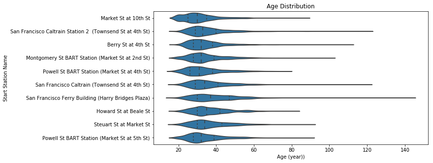

```python
start_order = bike_df['start_station_name'].value_counts().index[:10]
plt.figure(figsize=(10,5))
sb.violinplot(data=bike_df, y='start_station_name', x='age', inner='quartile', order = start_order, color=base_color)
x_y_t('Age (year))','Start Station Name','Age Distribution')
```

## Popular Days

### User bike rides based on days

Customer rides lasted longer than subscriber rides especially on weekends.  
The other gender had longer trips compared to males and females especially on the weekends.

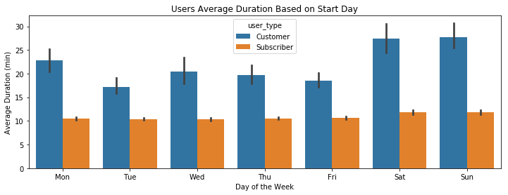

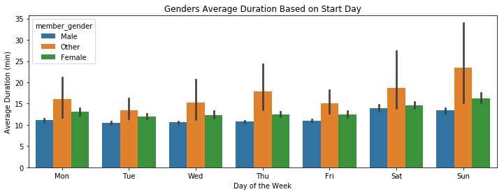

```python
plt.figure(figsize=[12,4])
sb.barplot(x="start_day",y="duration_minutes", hue ="user_type", data=bike_df);
plt.xticks(np.arange(0,7), day_labels)
x_y_t('Day of the Week','Average Duration (min)','Users Average Duration Based on Start Day')


plt.figure(figsize=[12,4])
sb.barplot(x="start_day",y="duration_minutes", hue ="member_gender", data=bike_df);
plt.xticks(np.arange(0,7), day_labels)
x_y_t('Day of the Week','Average Duration (min)','Genders Average Duration Based on Start Day')
```